# Lenguajes_de_Programación_Entrega_II

Esta parte del código se refiere a la manipulación previa de los datos para el análisis de los precios hedónicos (a parte de datos de Foursquare y obtenidos a través de webcrawler) donde se ha hecho scrap utilizando beautiful soup y transformado los datos para poder asignar un vecindario común y de ahí poder hacer el análisis de los datos.

Empezamos haciendo un scrap utilizando beautiful soup para recoger datos de hoteles de Berlin en Trip Advisor.

```python
import requests
from bs4 import BeautifulSoup
import pandas as pd
import csv
```

```python
# Extraemos el html y creamos el objeto soup
url = ('https://www.tripadvisor.es/Hotels-g187323-Berlin-Hotels.html')

user_agent = ({'User-Agent':
			'Mozilla/5.0 (Windows NT 10.0; Win64; x64) \
			AppleWebKit/537.36 (KHTML, like Gecko) \
			Chrome/90.0.4430.212 Safari/537.36',
			'Accept-Language': 'en-US, en;q=0.5'})

def get_page_contents(url):
    page = requests.get(url, headers = user_agent)
    return BeautifulSoup(page.text, 'html.parser')

soup = get_page_contents(url)
```

```python
# Extraímos los elementos de los datos
hotels = []
for name in soup.findAll('div',{'class':'listing_title'}):
    hotels.append(name.text.strip())
ratings = []
for rating in soup.findAll('a',{'class':'ui_bubble_rating'}):
    ratings.append(rating['alt'])
reviews = []
for review in soup.findAll('a',{'class':'review_count'}):
    reviews.append(review.text.strip())
prices = []
for p in soup.findAll('div',{'class':'price-wrap'}):
    prices.append(p.text.replace('&quot;', 'TWD').strip())
```

```python
latitudes = []
longitudes = []

# Intento encontrar todos elementos div para saber si encuentro las latitudes y longitudes
elements = soup.find_all('div',{'data-map-position':True})

# Iteramos los elementos
for element in elements:
    # Intentamos extraer la latitud y longitud
    lat_str = element['data-map-position']
    lat_dict = {}
    lng_dict = {}

    for entry in lat_str.split(','):
        key, value = entry.split(':')
        key = key.replace('&quot;', '')

        if key == 'latitude':
            lat_dict[key] = value
        elif key == 'longitude':
            lng_dict[key] = value

    # aunamos latitudes y longitudes a una lista, sin embargo, nos retorna vacío
    latitudes.append(lat_dict.get('latitude', ''))
    longitudes.append(lng_dict.get('longitude', ''))
```

```python
# Creamos el diccionario de las categorías que no están vacías
dict = {'Hotel Names':hotels,'Ratings':ratings,'Number of Reviews':reviews,'Prices':prices}
```

```python
# Creamos el dataframe
berlin= pd.DataFrame.from_dict(dict)
berlin.head(10)
```

|  | Hotel Names | Ratings | Number of Reviews | Prices |
| --- | --- | --- | --- | --- |
| 0 | Patrocinado Precise Tale Berlin Potsdamer... | 3,5 de 5 burbujas | 13 opiniones | 4.610 TWD |
| 1 | 1. Grand Hyatt Berlin | 4,5 de 5 burbujas | 4.295 opiniones |  |
| 2 | 2. The Mandala Hotel | 4,5 de 5 burbujas | 3.468 opiniones |  |
| 3 | 3. KPM Hotel & Residences | 5 de 5 burbujas | 370 opiniones |  |
| 4 | 4. Scandic Berlin Potsdamer Platz | 4,5 de 5 burbujas | 4.876 opiniones |  |
| 5 | 5. Park Inn by Radisson Berlin Alexanderplatz ... | 3,5 de 5 burbujas | 11.661 opiniones |  |
| 6 | 6. Hotel Adlon Kempinski Berlin | 4,5 de 5 burbujas | 4.731 opiniones |  |
| 7 | 7. 25hours Hotel Bikini Berlin | 4,5 de 5 burbujas | 2.524 opiniones |  |
| 8 | 8. Meliá Berlin | 4,5 de 5 burbujas | 7.013 opiniones |  |
| 9 | 9. Hotel Palace Berlin | 4,5 de 5 burbujas | 2.995 opiniones |  |

```python
# Lo convierto a csv para poder utilizarlo en la regresión hedónica
berlin.to_csv('hotels.csv', index=False, header=True)
df = pd.read_csv('/content/hotels.csv')
df = df.drop(df.columns[[3]], axis=1)
```

```python
df.head()
```

|  | Hotel Names | Ratings | Number of Reviews |
| --- | --- | --- | --- |
| 0 | Patrocinado Precise Tale Berlin Potsdamer... | 3,5 de 5 burbujas | 13 opiniones |
| 1 | 1. Grand Hyatt Berlin | 4,5 de 5 burbujas | 4.295 opiniones |
| 2 | 2. The Mandala Hotel | 4,5 de 5 burbujas | 3.468 opiniones |
| 3 | 3. KPM Hotel & Residences | 5 de 5 burbujas | 370 opiniones |
| 4 | 4. Scandic Berlin Potsdamer Platz | 4,5 de 5 burbujas | 4.876 opiniones |

```python
# Limpio la bbdd haciendo una función para reemplazar "de 5 burbujas" con un string vacío
def clean_ratings(s):
    return s.replace("de 5 burbujas", "")

# Aplico la función a la columna Ratings
df["Ratings"] = df["Ratings"].apply(clean_ratings)
```

```python
# Defino una función que reemplaza coma por puntos y convierte string a float
def convert_to_float(s):
    return float(s.replace(",", "."))

# Aplico a la columna ratings
df["Ratings"] = df["Ratings"].apply(convert_to_float)
```

```python
#hago la función para reemplazar opiniones por string
def clean_ratings(s):
    return s.replace("opiniones", "")

# Hago lo mismo para opiniones para quitar la palabra opiniones tras los numeros y aplico la función
df["Number of Reviews"] = df["Number of Reviews"].apply(clean_ratings)
```

```python
#lo salvo para utilizar más tarde
df.to_csv("modified_hotels.csv", index=False)

df.head()
```

[output not shown]

```python
import pandas as pd
import numpy as np
```

```python
# cargo el dataset recogido con webcrawler
df1 = pd.read_csv('/content/tripadvisorberlinhotel.csv')
df1.head()
```

|  | Name | Address | Latitude | Longitude | Provider1 | Providerprice1 | Provider2 | Providerprice2 | Provider3 | Providerprice3 | Provider4 | Providerprice4 | Provider5 | Providerprice5 | URL |
| --- | --- | --- | --- | --- | --- | --- | --- | --- | --- | --- | --- | --- | --- | --- | --- |
| 0 | Hotel Adlon Kempinski Berlin | Unter den Linden 77, 10117 Berlín Alemania | 52.516117 | 13.380286 | Tripadvisor | 477.8600 | Booking.com | NaN | Hotels.com | NaN | Agoda.com | NaN | Expedia | NaN | https://www.tripadvisor.es/Hotel_Review-g18732... |
| 1 | Regent Berlin | Charlottenstrasse 49, 10117 Berlín Alemania | 52.515285 | 13.390961 | RegentHotels | 381.1729 | Booking.com | NaN | Hotels.com | NaN | Agoda.com | NaN | Expedia | NaN | https://www.tripadvisor.es/Hotel_Review-g18732... |
| 2 | Waldorf Astoria Berlin | Hardenbergstrasse 28, 10623 Berlín Alemania | 52.505791 | 13.332745 | Tripadvisor | 380.7900 | Booking.com | NaN | Hotels.com | NaN | Agoda.com | NaN | Expedia | NaN | https://www.tripadvisor.es/Hotel_Review-g18732... |
| 3 | SO/ Berlin Das Stue | Drakestr. 1, 10787 Berlín Alemania | 52.509697 | 13.346161 | Sofitel | 374.1998 | Booking.com | NaN | Hotels.com | NaN | Expedia | 392.0775 | Agoda.com | NaN | https://www.tripadvisor.es/Hotel_Review-g18732... |
| 4 | Myer's Hotel - Berlin | Metzer Str. 26, 10405 Berlín Alemania | 52.531342 | 13.418141 | Tripadvisor | 265.6000 | Booking.com | NaN | Hotels.com | NaN | Expedia | 277.7576 | Agoda.com | NaN | https://www.tripadvisor.es/Hotel_Review-g18732... |

```python
#elimino las columnas que no voy a utilizar
df1 = df1.drop(df1.columns[[1, 4, 6, 7, 8, 9, 10, 11, 12, 13, 14]], axis=1)
```

```python
df1.head()
```

|  | Name | Latitude | Longitude | Providerprice1 |
| --- | --- | --- | --- | --- |
| 0 | Hotel Adlon Kempinski Berlin | 52.516117 | 13.380286 | 477.8600 |
| 1 | Regent Berlin | 52.515285 | 13.390961 | 381.1729 |
| 2 | Waldorf Astoria Berlin | 52.505791 | 13.332745 | 380.7900 |
| 3 | SO/ Berlin Das Stue | 52.509697 | 13.346161 | 374.1998 |
| 4 | Myer's Hotel - Berlin | 52.531342 | 13.418141 | 265.6000 |

```python
#ahora intentaré asignar las direcciones a través de latitud y longitud utilizando nominatim

from geopy.geocoders import Nominatim

# Creo un objeto de geolocalización
geolocator = Nominatim(user_agent="my_app")

# Hago loop
for index, row in df1.iterrows():
  # cojo las latitudes y longitudes de los hoteles
  latitude = row['Latitude']
  longitude = row['Longitude']

  # atribuo una localización a esta latitud y longitud
  location = geolocator.reverse(f"{latitude}, {longitude}")

  # busco si la dirección está en el diccionario clave
  if 'address' in location.raw:
    # busco si el vecindario está en el diccionario clave
    if 'neighbourhood' in location.raw['address']:
      # uso el vecindario para coger la dirección
      neighborhood = location.raw['address']['neighbourhood']
    else:
      # uso unkown si no hay vecindario
      neighborhood = "unknown"
```

```python
#salvo para utilizar en la regresión
df1.to_csv("triptransformado.csv", index=False)

df1.head()
```

|  | Name | Latitude | Longitude | Providerprice1 | neighborhood |
| --- | --- | --- | --- | --- | --- |
| 0 | Hotel Adlon Kempinski Berlin | 52.516117 | 13.380286 | 477.8600 | unknown |
| 1 | Regent Berlin | 52.515285 | 13.390961 | 381.1729 | unknown |
| 2 | Waldorf Astoria Berlin | 52.505791 | 13.332745 | 380.7900 | unknown |
| 3 | SO/ Berlin Das Stue | 52.509697 | 13.346161 | 374.1998 | Botschaftsviertel |
| 4 | Myer's Hotel - Berlin | 52.531342 | 13.418141 | 265.6000 | Kollwitzkiez |

```python
#cambio el nombre de las columnas del primero archivo para que pueda hacer un merge con el segundo archivo
df1 = df1.rename(columns={"neighborhood": "neighbourhood"})
```

```python
df1.head()
```

|  | Name | Latitude | Longitude | Providerprice1 | neighbourhood |
| --- | --- | --- | --- | --- | --- |
| 0 | Hotel Adlon Kempinski Berlin | 52.516117 | 13.380286 | 477.8600 | unknown |
| 1 | Regent Berlin | 52.515285 | 13.390961 | 381.1729 | unknown |
| 2 | Waldorf Astoria Berlin | 52.505791 | 13.332745 | 380.7900 | unknown |
| 3 | SO/ Berlin Das Stue | 52.509697 | 13.346161 | 374.1998 | Botschaftsviertel |
| 4 | Myer's Hotel - Berlin | 52.531342 | 13.418141 | 265.6000 | Kollwitzkiez |

```python
df1.head()
```

[output not shown]

```python
#para poder hacer un merge con el nombre de los hoteles, como no coinciden exactamente, installo fuzzywuzzy
pip install fuzzywuzzy
```

```python
from fuzzywuzzy import fuzz
```

```python
import string

def preprocess_tokens(tokens):
    # Convierto los tokens a lower case
    tokens = [token.lower() for token in tokens]
    # Remuevo la puntuación
    table = str.maketrans("", "", string.punctuation)
    tokens = [token.translate(table) for token in tokens]
    # Remuevo espacios en blanco
    tokens = [token for token in tokens if token]
    return tokens

# Preproceso los tokens en la columna Name en ambos df
df["name"] = df["Name"].apply(preprocess_tokens)
df1["name"] = df1["Name"].apply(preprocess_tokens)
```

```python
#quiero que haga un match por parecido de nombre
matched_rows = []

# Itero las filas del primer dataframe
for i, row1 in df.iterrows():
    # Cojo los nombres del primer dataframe
    name1 = row1["Name"]
    max_similarity = 0
    match_index = None
    # Itero las filas del segundo dataframe
    for j, row2 in df1.iterrows():
        # Cojo los nombres de los segundos dataframe
        name2 = row2["Name"]
        # Calculamos la similitud de los strings entre los dos dataframes
        similarity = fuzz.token_sort_ratio(name1, name2)
        # Si la similitud es superior al máximo que se ha medido, se almacena en el índice
        if similarity > max_similarity:
            max_similarity = similarity
            match_index = j
```

```python
df["Name"] = df["Name"].apply(lambda tokens: " ".join(tokens))
df_matched["Name"] = df_matched["Name"].apply(lambda tokens: " ".join(tokens))
```

```python
# y hacemos merge entre los dataframes
df_merged = pd.merge(df1, df2, on="neighbourhood")
```

```python
#me ha regresado vacía, por lo que usaré los precios y las latitudes y longitudes y descartaré los numeros de reviews y ratings
df_merged.head()
```

|  | Name | Latitude | Longitude | Providerprice1 | neighbourhood | id | name | host_id | host_name | neighbourhood_group | ... | room_type | price | minimum_nights | number_of_reviews | last_review | reviews_per_month | calculated_host_listings_count | availability_365 | number_of_reviews_ltm | license |
| --- | --- | --- | --- | --- | --- | --- | --- | --- | --- | --- | --- | --- | --- | --- | --- | --- | --- | --- | --- | --- | --- |

0 rows × 22 columns

```python
# ahora para hacer el análisis k-means, cargo la base de datos de listing de AirBnB
df2 = pd.read_csv('/content/listings.csv')
df2.head()
```

|  | id | name | host_id | host_name | neighbourhood_group | neighbourhood | latitude | longitude | room_type | price | minimum_nights | number_of_reviews | last_review | reviews_per_month | calculated_host_listings_count | availability_365 | number_of_reviews_ltm | license |
| --- | --- | --- | --- | --- | --- | --- | --- | --- | --- | --- | --- | --- | --- | --- | --- | --- | --- | --- |
| 0 | 2818 | Quiet Garden View Room & Super Fast WiFi | 3159 | Daniel | NaN | Oostelijk Havengebied - Indische Buurt | 52.36435 | 4.94358 | Private room | 49 | 3 | 305 | 2022-08-30 | 1.86 | 1 | 14 | 25 | 0363 5F3A 5684 6750 D14D |
| 1 | 20168 | Studio with private bathroom in the centre 1 | 59484 | Alexander | NaN | Centrum-Oost | 52.36407 | 4.89393 | Private room | 106 | 1 | 339 | 2020-04-09 | 2.22 | 2 | 0 | 0 | 0363 CBB3 2C10 0C2A 1E29 |
| 2 | 27886 | Romantic, stylish B&B houseboat in canal district | 97647 | Flip | NaN | Centrum-West | 52.38761 | 4.89188 | Private room | 136 | 2 | 231 | 2022-04-24 | 1.78 | 1 | 121 | 8 | 0363 974D 4986 7411 88D8 |
| 3 | 28871 | Comfortable double room | 124245 | Edwin | NaN | Centrum-West | 52.36775 | 4.89092 | Private room | 75 | 2 | 428 | 2022-08-24 | 2.92 | 2 | 117 | 75 | 0363 607B EA74 0BD8 2F6F |
| 4 | 29051 | Comfortable single room | 124245 | Edwin | NaN | Centrum-Oost | 52.36584 | 4.89111 | Private room | 55 | 2 | 582 | 2022-08-29 | 4.16 | 2 | 160 | 86 | 0363 607B EA74 0BD8 2F6F |

```python
#elimino valores nulos de las columnas latitud, longitud y precio
df2 = df2.dropna(subset=['latitude', 'longitude', 'price'])
```

```python
#elimino los valores outliers

# Calculamos el percentil 25th y 75th
q1 = df2.quantile(0.25)
q3 = df2.quantile(0.75)

# calculamos iqr
iqr = q3 - q1

# Calculamos el lower bound y el upper bound
lower_bound = q1 - (iqr * 3)
upper_bound = q3 + (iqr * 3)

# Removemos los datos con outliers (nos quedamos con solo los por encima del lower y por debajo del upper bound)
df3 = df2[(df2 > lower_bound) & (df2 < upper_bound)]
```

```python
df3.head()
```

|  | id | name | host_id | host_name | neighbourhood_group | neighbourhood | latitude | longitude | room_type | price | minimum_nights | number_of_reviews | last_review | reviews_per_month | calculated_host_listings_count | availability_365 | number_of_reviews_ltm | license |
| --- | --- | --- | --- | --- | --- | --- | --- | --- | --- | --- | --- | --- | --- | --- | --- | --- | --- | --- |
| 0 | 2818.0 | NaN | 3159 | NaN | NaN | NaN | 52.36435 | 4.94358 | NaN | 49.0 | 3.0 | NaN | NaN | 1.86 | NaN | 14 | 25.0 | NaN |
| 1 | 20168.0 | NaN | 59484 | NaN | NaN | NaN | 52.36407 | 4.89393 | NaN | 106.0 | 1.0 | NaN | NaN | 2.22 | NaN | 0 | 0.0 | NaN |
| 2 | 27886.0 | NaN | 97647 | NaN | NaN | NaN | 52.38761 | 4.89188 | NaN | 136.0 | 2.0 | NaN | NaN | 1.78 | NaN | 121 | 8.0 | NaN |
| 3 | 28871.0 | NaN | 124245 | NaN | NaN | NaN | 52.36775 | 4.89092 | NaN | 75.0 | 2.0 | NaN | NaN | 2.92 | NaN | 117 | NaN | NaN |
| 4 | 29051.0 | NaN | 124245 | NaN | NaN | NaN | 52.36584 | 4.89111 | NaN | 55.0 | 2.0 | NaN | NaN | 4.16 | NaN | 160 | NaN | NaN |

```python
from sklearn.cluster import KMeans
import pandas as pd


# extraigo la latitud y longitud
X = df2[['latitude', 'longitude']].values

# Defino y hago fit al kmeans con 9 grupos (porque hay muchos vecindarios)
kmeans = KMeans(n_clusters=9)
kmeans.fit(X)

# Añado una etiqueta llamada cluster
df2['cluster'] = kmeans.labels_

# Calculo el promedio de los precios por vecindario
cluster_prices = df2.groupby('cluster')['price'].mean()
print(cluster_prices)
```

```
cluster
0    245.253968
1    195.914110
2    141.635359
3    194.292553
4    177.450980
5    186.774074
6    257.486618
7    184.750925
8    220.066667
Name: price, dtype: float64
```

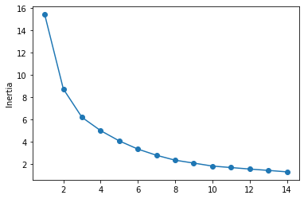

```python
#si quisiera ver el numero ideal de clusters con el metodo elbow

X = df2[['latitude', 'longitude']].values

# inicializamos las inercias para cada valor de k
inertias = []

# Iteramos sobre un rango de valores k
for k in range(1, 15):
    # cogemos el algoritmo k-means  empezando con 1
    kmeans = KMeans(n_clusters=k)
    kmeans.fit(X)

    # almacenamos la inercia
    inertias.append(kmeans.inertia_)

# graficamos
plt.plot(range(1, 15), inertias, '-o')

plt.ylabel('Inertia')

plt.show()
```